# Title

#### Alaska

As mentioned earlier, Alaska exhibited high suicide rates despite having relatively high provider availability. To better understand this paradox, we conducted a more focused analysis on Alaskan counties.

In the choropleth maps below, we observe that many Alaskan counties report a high number of poor mental health days, despite having a greater density of mental health providers compared to other regions. This further supports the earlier finding that provider access alone may not be sufficient to mitigate mental health challenges, particularly in geographically isolated areas.

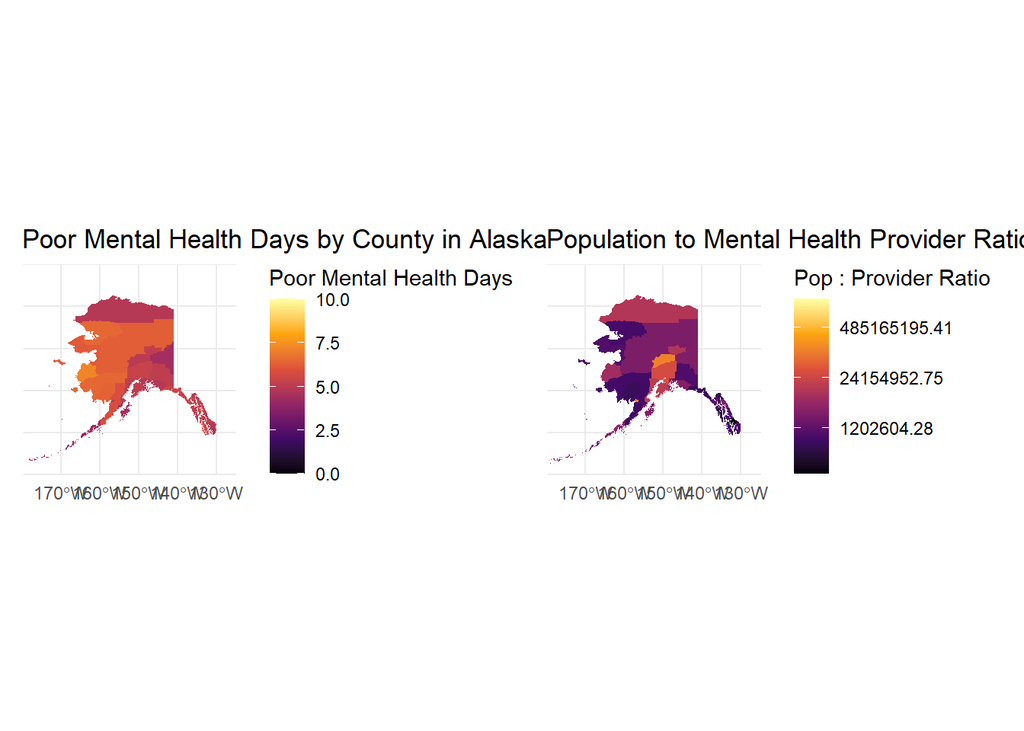

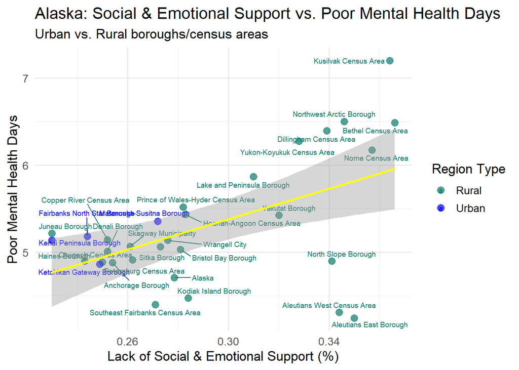

This regional disparity points to broader social determinants of health, such as community isolation, economic opportunity, and access to nonclinical support systems, that likely contribute to elevated mental health struggles in rural Alaska. It also raises important questions about the effectiveness and reach of mental health services in remote communities and highlights social and emotional support as a potentially more critical factor in improving mental health outcomes.

## Methods

### Quasi-Poisson Regression

We first fit a Poisson linear model because ‘poor_mental_days’ is a non-negative count variable.

$$\log(\mu_i) \;=\; \beta_0
+ \beta_1 x_{1i}
+ \beta_2 x_{2i}
+ \beta_3 x_{3i}
+ \beta_4 x_{4i}$$

where

$x_1$ = provider–population ratio  
$x_2$ = feelings of loneliness  
$x_3$ = lack of social support  
$x_4$= suicide rate

#### Inference and interpretation

coefficients from the quasi‑Poisson fit were converted to **percent change in poor‑mental‑health days per 1‑SD increase** in each predictor. Significance was judged by 95% confidence intervals that excludes 0% change.

Quasi‑Poisson regression: percent change in poor‑mental‑health days per 1‑SD increase

| Predictor | % Change | 95% CI Lower | 95% CI Upper | p‑value |
| --- | --- | --- | --- | --- |
| Provider Ratio | 1.18 | 0.75 | 1.61 | 0 |
| Loneliness (0–1 Scale) | 3.54 | 2.99 | 4.10 | 0 |
| Lack of Social Support (0–1 Scale) | 0.92 | 0.34 | 1.51 | 0 |
| Suicide Rate | 1.78 | 1.38 | 2.19 | 0 |

### 2 Machine‑learning models for prediction

Since we had a large sample, we decided to implement some machine learning to create predictive models. We selected Random Forest and XGBoost and evaluated them using RMSE. The lower the RMSE, the more accurate the predictions.

Since we had a large sample, we decided to implement some machine learning to create predictive models. We selected Random Forest and XGBoost and evaluated them use RMSE. The lower the RMSE is the better the model is. We also used % increase in RMSE to evaluate feature importance. The greater the % increase is, the greater the importance it has in the model.

## Results

Alaska Scatterplot: Social & Emotional Support vs. Poor Mental Health Days

After analyzing findings from the previous plot, which found that Alaskan counties (or boroughs/census areas) seem to have significantly higher suicide rates than other US counties, we did a more in-depth analysis with this scatterplot filtering for only Alaskan boroughs/census areas using two other key variables: poor mental health days and lack of social & emotional support (both raw value counts). We also color coded by region type, differentiating rural from urban regions.

```
 [1] "Alaska"                            "Aleutians East Borough"
 [3] "Aleutians West Census Area"        "Anchorage Borough"
 [5] "Bethel Census Area"                "Bristol Bay Borough"
 [7] "Chugach Census Area"               "Copper River Census Area"
 [9] "Denali Borough"                    "Dillingham Census Area"
[11] "Fairbanks North Star Borough"      "Haines Borough"
[13] "Hoonah-Angoon Census Area"         "Juneau Borough"
[15] "Kenai Peninsula Borough"           "Ketchikan Gateway Borough"
[17] "Kodiak Island Borough"             "Kusilvak Census Area"
[19] "Lake and Peninsula Borough"        "Matanuska-Susitna Borough"
[21] "Nome Census Area"                  "North Slope Borough"
[23] "Northwest Arctic Borough"          "Petersburg Census Area"
[25] "Prince of Wales-Hyder Census Area" "Sitka Borough"
[27] "Skagway Municipality"              "Southeast Fairbanks Census Area"
[29] "Wrangell City"                     "Yakutat Borough"
[31] "Yukon-Koyukuk Census Area"
```

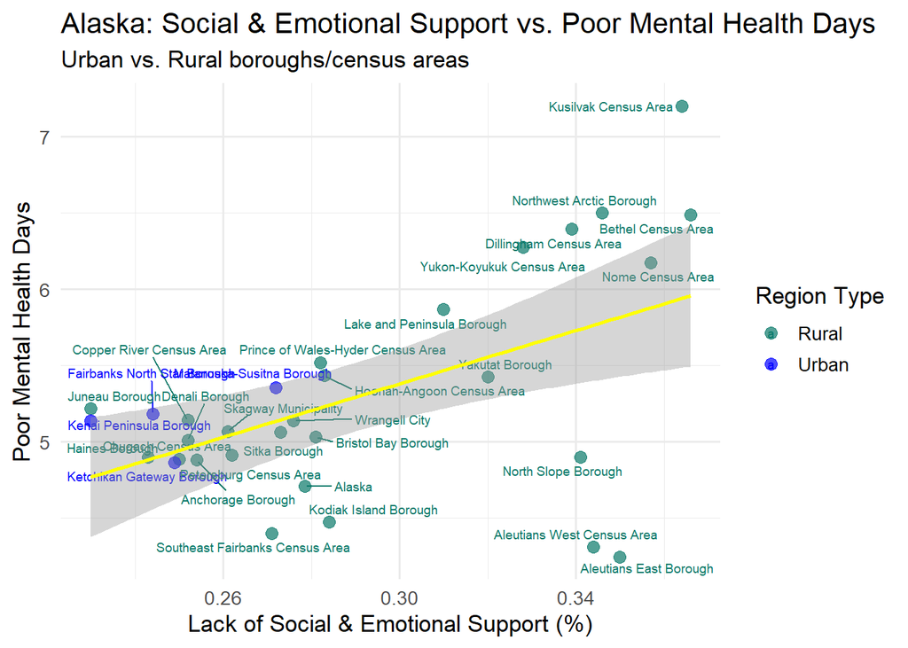

Test‑set prediction error for each model

| Model | MSE | RMSE |
| --- | --- | --- |
| Random Forest | 0.212 | 0.460 |
| XGBoost | 0.196 | 0.443 |

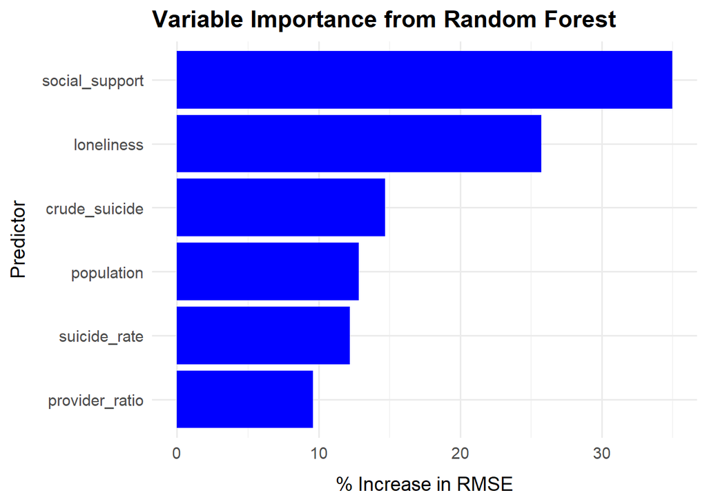

[output not shown]

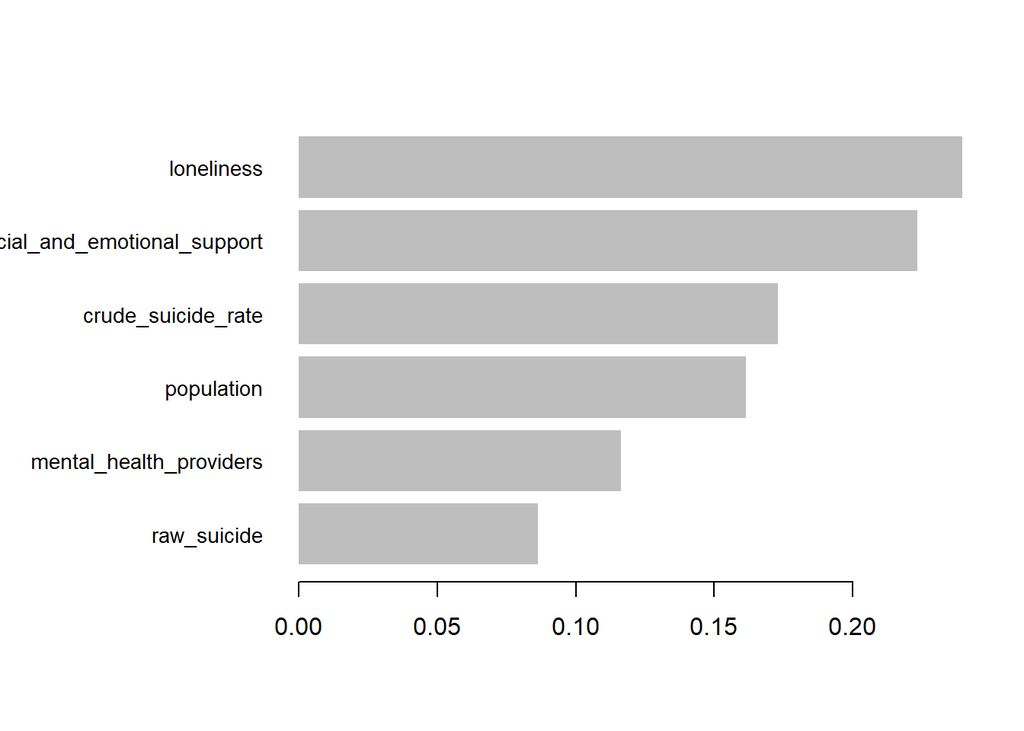

[output not shown]

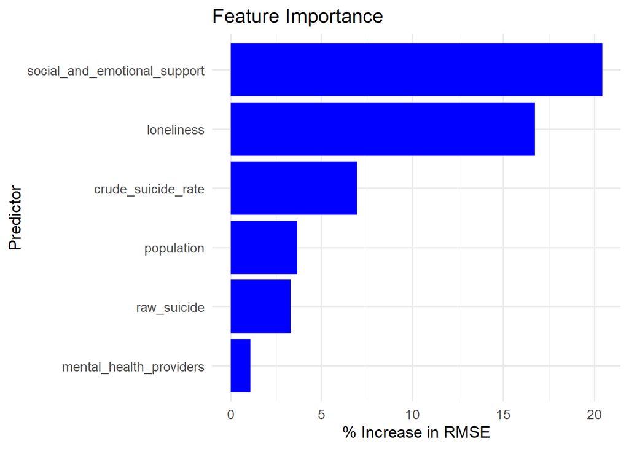

## Recommendations

1. Partner with particular state and local governments to improve broadband access (subsidized mobile hotspots, data plans, etc.). Many rural communities have the opportunity to utilize telehealth platforms but lack the internet infrastructure to support it.
2. Invest in virtual therapy platforms that can connect individuals to licensed mental health providers. In-person care is limited or sometimes unavailable in rural regions for a variety of reasons, making this method of care critical for many in these communities.
3. Develop community peer-support networks, to be paired with virtual therapy. Our findings show that connectedness and social support are some of the strongest predictors of a good mental state. Community leaders and members could stand to provide social and emotional support in meetings and organized events, virtually or in-person.

Our recommendations shift the focus from solving mental health problems with only clinical interventions to a community-based, social approach. Planning investments and developments in these areas keeps the focus and support on the individual. This gives UHG/Optum the opportunity to better support these notably underserved areas and make a real impact, where many traditional, in-person models have not been enough.

## Discussion

### Research Summary

Our analysis found no strong correlation between mental health provider density and number of poor mental health days, challenging the common assumption that increasing the number of clinical providers will lead to better mental health outcomes overall. This told us that there are other variables playing a bigger role here. Among the group tested, feelings of loneliness and lack of social and emotional support led as the strongest predictors of poor mental health days. Taking a further step with our findings, we discovered an alarming pattern in Alaskan counties, pointing to disparities in mental health outcomes between their urban and rural regions. This new view reinforced the importance of the social determinants of health and helped direct our discussions and recommendations. When comparing predictive models, we found XGBoost to be a better predictive model, as it captured the non-linear relationships between all our variables better. This suggests that more advanced machine learning methods could offer a better understanding of complex subjects like mental health.

### Limitations

A main limitation of our work is our use of aggregated, county-level data, so variation on an individual/personal level is unknown. Population-level associations might not accurately reflect what happens at the individual level, making it harder to design effective care strategies. Our dataset lacked variables on broader social determinants, as we mainly used lack of social and emotional support to draw conclusions on social implications. Variables like housing/food insecurity and trauma exposure were not included and because of that, we were not able to fully interpret the true care accessibility issues going on, on the national and county levels. Lacking mental health provider metrics also made our analysis of clinical variables slightly weaker. We were not able to assess the role of insurance rates in mental health outcomes, which could possibly direct future work into another key area as well.

### Next Steps

For future work, we believe using geographical factors, behavioral health indicators, and mental health provider metrics will be useful. Considering social (race, gender) and economic (income, insurance rates) factors could make for an even more valuable and insightful analysis. Exploring longitudinal data trends would also be useful when adopting machine learning for this type of analysis, that way patterns can be localized confidently in particular areas of interest. Future studies should seek individual-level data as well, to interpret the importance of personal/life experience and risk factors in order to account for how perceived support, discrimination, and stigma can affect mental health outcomes. Listening to individual perspectives and narratives allows for more accurate/empathetic understanding of disparities in mental health outcomes across the nation. Taking these future steps would open a door to even stronger clinical/behavioral health recommendations, all with the end goal of improving mental health outcomes for all people.

## Appendix

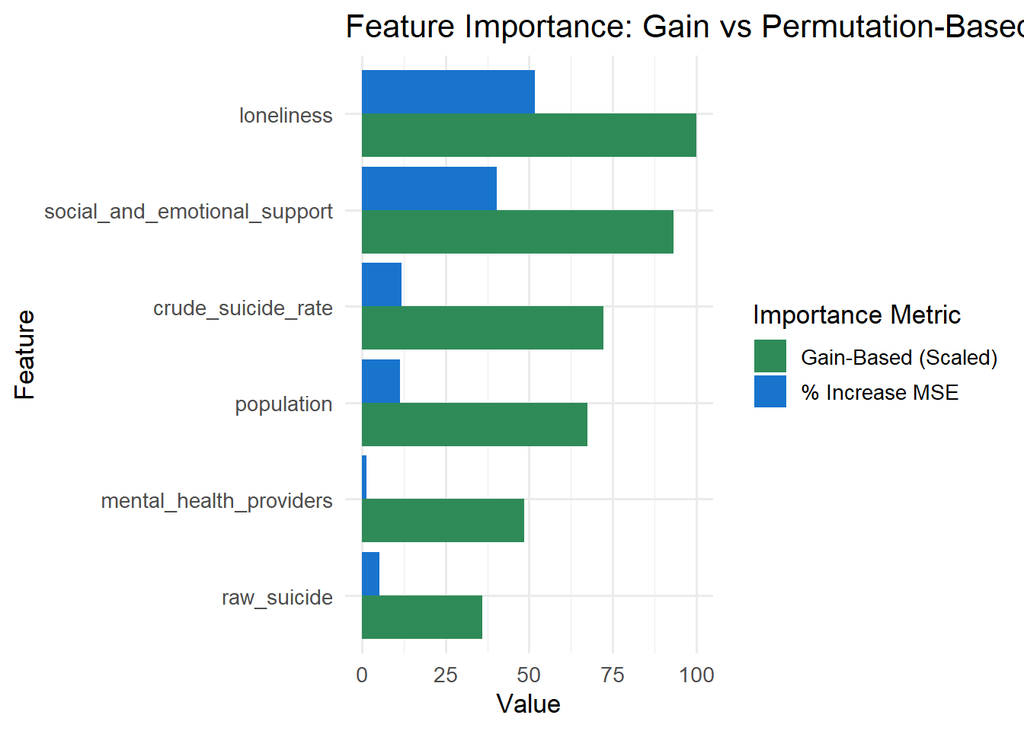

[output not shown]